# CHD2 Cortical Brain Organoids Day25 - DEGs overlap with NDD genes

## 5. Test for overlap enrichment

### 5.1 GWAS Risk Genes

For each disease, I select the genes that are found in the universe. Each gene is included only once.

```r
GeneVect <- list()

GeneVect$SFARI <- unique(GeneSets$SFARI$All$Symbol)[unique(GeneSets$SFARI$All$Symbol) %in% Universe]

GeneVect$DD <- unique(GeneSets$DD$Simple$GeneName)[unique(GeneSets$DD$Simple$GeneName) %in% Universe]
GeneVect$DD_B <- unique(GeneSets$DD$Brain$GeneName)[unique(GeneSets$DD$Brain$GeneName) %in% Universe]
```

### 5.2 Overlap Contingency Table

```r
OvObj <- newGOM(DEA, GeneVect, genome.size=length(Universe))
print(OvObj)
## A GeneOverlapMatrix object:
## ###### Intersection ######
##         SFARI  DD DD_B
## DEGs_HT   179 334  179
## DEGs_AR     0   0    0
## ###### P-value ######
##                SFARI      DD      DD_B
## DEGs_HT 3.675902e-05 0.15942 0.9239036
## DEGs_AR 1.000000e+00 1.00000 1.0000000
## ###### Odds Ratio ######
##            SFARI       DD     DD_B
## DEGs_HT 1.429087 1.068002 0.890976
## DEGs_AR 0.000000 0.000000 0.000000
## ###### Jaccard Index ######
##              SFARI         DD       DD_B
## DEGs_HT 0.05440729 0.07697626 0.04852263
## DEGs_AR 0.00000000 0.00000000 0.00000000
```

#### Intersection Numbers

```r
getMatrix(OvObj, name='intersection')
##         SFARI  DD DD_B
## DEGs_HT   179 334  179
## DEGs_AR     0   0    0
```

#### Intersection PValues

```r
getMatrix(OvObj, name='pval')
##                SFARI      DD      DD_B
## DEGs_HT 3.675902e-05 0.15942 0.9239036
## DEGs_AR 1.000000e+00 1.00000 1.0000000
```

#### Intersection Odds Ratios

```r
getMatrix(OvObj, name='odds.ratio')
##            SFARI       DD     DD_B
## DEGs_HT 1.429087 1.068002 0.890976
## DEGs_AR 0.000000 0.000000 0.000000
```

## 6. Visualize overlap enrichment

### 6.1 Overlap Heatmap

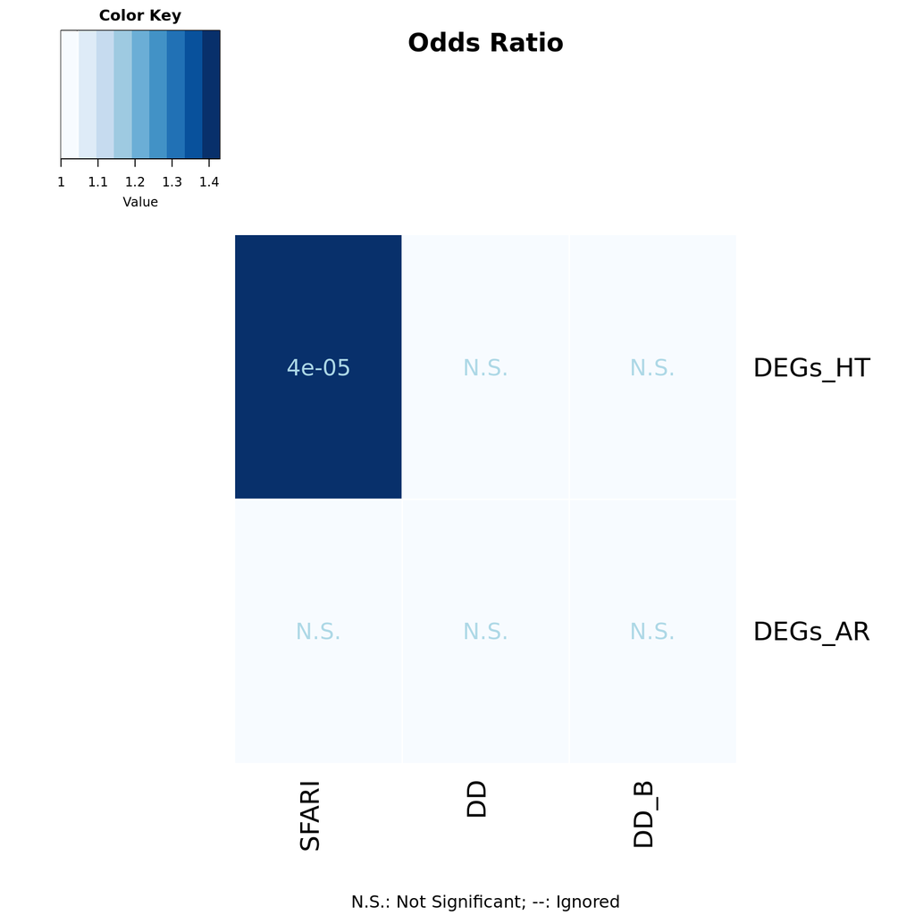

```r
drawHeatmap(OvObj, cutoff=0.05, note.col='lightblue', grid.col = 'Blues')
```

### 6.2 DotPlot

- Data are re-organized for visualization
- Only OR > 1 are kept for visualization
- Numbers are visualized for all categories passing the OR filter
- Coloured dot is shown only for categories passing a pvalue threshold of 0.05

```r
OR <- data.frame(getMatrix(OvObj, name='odds.ratio'))
OR$Module <- row.names(OR)
OR <- gather(OR, 'KBase', 'OR', -Module)

PVAL <- data.frame(getMatrix(OvObj, name='pval'))
PVAL$Module <- row.names(PVAL)
PVAL <- gather(PVAL, 'KBase', 'PVal', -Module)

NUM <- data.frame(getMatrix(OvObj, name='intersection'))
NUM$Module <- row.names(NUM)
NUM <- gather(NUM, 'KBase', 'Numbers', -Module)


if(! identical(OR$Module, PVAL$Module)){
  stop('Inconsistency')
}
if(! identical(OR$Module, NUM$Module)){
  stop('Inconsistency')
}
if(! identical(OR$KBase, NUM$KBase)){
  stop('Inconsistency')
}
if(! identical(OR$KBase, NUM$KBase)){
  stop('Inconsistency')
}


Res <- mutate(OR, Pval=PVAL$PVal) %>% mutate(Numbers=NUM$Numbers)

OR
NUM
```

```r
ResSel <- dplyr::filter(Res, OR > 1)

max(ResSel$OR)
## [1] 1.429087
max(-log10(ResSel$Pval))
## [1] 4.434636
```

```r
ResSel %>% dplyr::filter(Pval < 0.05)
```

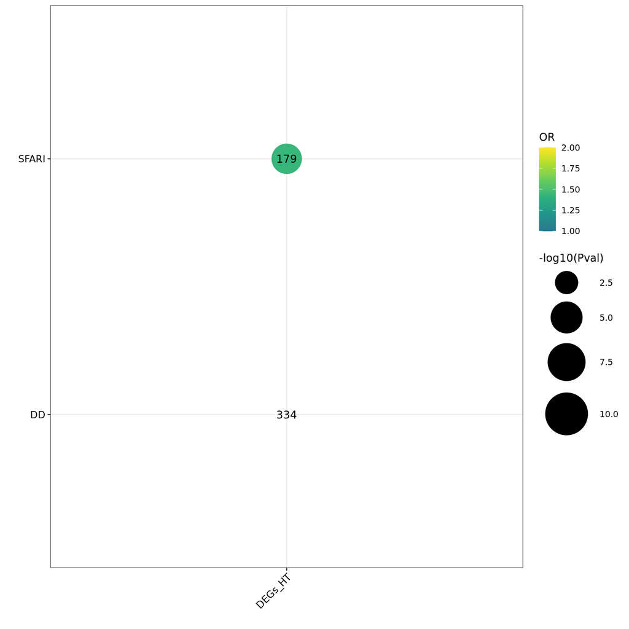

```r
cols <- viridis::cividis(100)[20:100]

Dot <- ggplot(ResSel, aes(Module, KBase, label=Numbers)) +
  geom_point(aes(size=-log10(Pval), col=OR)) +
  geom_text() +
  scale_size_continuous(range=c(5, 20), limits=c(-log10(0.05), 10)) +
  scale_color_viridis_c(limits=c(1, 2), begin=0.4) + xlab('') + ylab('') +
  theme_bw() +
  theme(axis.text.x = element_text(angle = 45, vjust = 1, hjust=1)) +
  theme(axis.text = element_text(size=10, color='black'))

Dot
```

```r
ggsave(Dot, filename=paste0(params$FiguresFolder, 'KB_NDD_ipsc.pdf'), width=6.5, height=6.5)
```

## 7. Overlapping gene identity

Check gene identity for each significant overlap.

### Heterozygous

- For **SFARI 179 overlapping genes**: ACE, AFF2, AGAP2, ANKS1B, ANXA1, APBA2, AR, ARHGAP24, ASAP2, ASMT, ASS1, ATRNL1, AUTS2, BBS4, BDNF, BRSK2, CACNA1E, CACNA1G, CACNA2D3, CADM1, CADM2, CAPN12, CASZ1, CBLN1, CD44, CHD3, CLN8, CLSTN2, CNKSR2, CNTNAP3, CTNNA2, CTNNA3, CYP27A1, DAGLA, DGKK, DLX3, DMPK, DMXL2, DNAH17, DOCK10, EBF3, EGR2, ELAVL2, EPHA6, ERG, F13A1, FABP7, FBN1, FHIT, FOXP2, GABRQ, GALNT14, GAP43, GATM, GPC6, GPD2, GRIA1, GRID2, GRIK2, GRIK3, GRIN1, GRIN2A, GRIN2B, GRM4, GRM8, GSN, GUCY1A2, HIVEP3, HLA-DRB1, HS3ST5, HTR3A, HTR7, HYDIN, IQSEC2, IRF2BPL, ITGA4, ITPR1, JARID2, KCNB1, KCND2, KCNQ2, KCNS3, KHDRBS2, KIAA1586, KIT, KMT2A, LAMA1, LAMB1, LAMC3, LMX1B, LRP2, LRRC4, MAOB, MAPK3, MCC, MDGA2, MED13, MEF2C, MSN, MYO1E, MYT1L, NAV2, NEFL, NEGR1, NEXMIF, NFIA, NLGN3, NOS2, NRCAM, NRG1, NRXN2, NTRK3, OTX1, P2RX5, PAH, PARD3B, PAX5, PCDH10, PCDH11X, PCDHA11, PCDHA13, PCDHA6, PCDHAC1, PCDHAC2, PDCD1, PLAUR, PLPPR4, PLXNA4, PPP1R1B, PPP1R3F, PRICKLE1, PRICKLE2, PRKCA, PRKCB, PRODH, PRUNE2, PTPRB, RAB43, RAI1, RBMS3, RIMS1, ROBO2, RPP25, RPS6KA2, SATB2, SCN2A, SDC2, SEMA3F, SEMA5A, SERPINE1, SLC16A3, SLC16A7, SLC22A3, SLC25A14, SLC25A27, SLC29A4, SLC30A3, SLC6A3, SLITRK5, ST8SIA2, SYN1, SYN3, SYT17, SYT3, TANC2, TBX1, TCF7L2, TET2, THBS1, TRPC6, TSHZ3, TSPOAP1, TTN, TUBGCP5, UNC80, VIL1, WASF1, XPO1, ZNF18
- For **ADHD 179 overlapping genes**: AASS, ABCD1, ACTG1, AFF2, ALDH1A3, ALMS1, ANKH, AR, ARL6, ARSL, ASCC3, ASNS, ATM, ATP8A2, AUTS2, BBS10, BBS4, BBS9, BCOR, BRSK2, CA2, CA8, CACNA1E, CACNA1G, CCDC8, CCDC88A, CHD3, CHRNB2, CLN8, CNKSR2, COL4A2, COL9A3, CPLANE1, CPS1, CRB2, CTNNA2, CYP27A1, CYP2U1, DHRS3, DLL1, EBF3, EEF1A2, EIF2AK2, ENTPD1, EOMES, FAM111A, FAM20C, FDFT1, FGF12, FLVCR2, FMN2, FOLR1, FOXP2, FOXP4, FREM1, FRMPD4, FRRS1L, FRY, GATM, GCH1, GLDC, GMPPA, GNPTAB, GRIA1, GRIA3, GRIK2, GRIN1, GRIN2A, GRIN2B, GRM1, HCN1, HGSNAT, HMGB3, HPDL, IDS, IDUA, IFIH1, IQSEC2, IRF2BPL, ITPR1, JARID2, KCNA2, KCNB1, KCNC3, KCNJ6, KCNQ2, KCNQ5, KLF8, KMT2A, LAMA1, LAMB1, LAMC3, LARP7, LINGO1, LRAT, LRP2, MAF, MAPK10, MAT1A, MED13, MEF2C, MMAA, MMADHC, MN1, MRAS, NBAS, NEU1, NEXMIF, NFIA, NFIX, NKX6-2, NLGN3, NOVA2, NRXN2, NTNG2, OTX2, P4HTM, PAH, PAK1, PAX8, PDE10A, PDGFRB, PGAP1, PIGB, PLA2G6, PPP3CA, PTCH1, PURA, RAI1, RAX, RIMS2, RIN2, RNASET2, ROR2, RORB, RRAS, RYR3, SACS, SATB2, SCN1B, SCN2A, SDCCAG8, SLC13A5, SLC16A2, SLC19A3, SLC25A20, SLC39A8, SLC6A3, SMARCA2, SMOC1, SMPD1, SOBP, SOX10, SOX11, SPTBN4, SRPX2, ST3GAL3, STRA6, SYN1, SYP, TBX1, TCTN1, TKT, TMEM106B, TMEM67, TRNT1, TUBA1A, TUBB2B, TUBB3, TUBB4A, UGP2, UNC80, USP18, USP9X, WASF1, WDPCP, WNT3, WNT4, ZMIZ1

#### SFARI

```r
overlapSFARI_1 <- paste0(sort(intersect(DEA$DEGs_HT, GeneVect$SFARI)))
print('Genes present in the overlap for SFARI:')
## [1] "Genes present in the overlap for SFARI:"
DT::datatable(as.data.frame(overlapSFARI_1), class = "hover", colnames = "",
              escape = FALSE, caption = "Heterozygous (SFARI)",
              options = list(autoWidth = TRUE, dom = "Bfrtip"))
```

| 1 | ACE |
| --- | --- |
| 2 | AFF2 |
| 3 | AGAP2 |
| 4 | ANKS1B |
| 5 | ANXA1 |
| 6 | APBA2 |
| 7 | AR |
| 8 | ARHGAP24 |
| 9 | ASAP2 |
| 10 | ASMT |

[output cut: 169 more lines]

#### ADHD

```r
overlapADHD_1 <- paste0(sort(intersect(DEA$DEGs_HT, GeneVect$DD_B)))
print('Gene present in the overlap for ADHD:')
## [1] "Gene present in the overlap for ADHD:"
DT::datatable(as.data.frame(overlapADHD_1), class = "hover", colnames = "",
              escape = FALSE, caption = "Heterozygous (ADHD)",
              options = list(autoWidth = TRUE, dom = "Bfrtip"))
```

| 1 | AASS |
| --- | --- |
| 2 | ABCD1 |
| 3 | ACTG1 |
| 4 | AFF2 |
| 5 | ALDH1A3 |
| 6 | ALMS1 |
| 7 | ANKH |
| 8 | AR |
| 9 | ARL6 |
| 10 | ARSL |

[output cut: 169 more lines]

### Ancestral

- For **SFARI 0 overlapping genes**:
- For **ADHD 0 overlapping genes**:

#### SFARI

```r
overlapSFARI_2 <- paste0(sort(intersect(DEA$DEGs_AR, GeneVect$SFARI)))
print('Genes present in the overlap for SFARI:')
## [1] "Genes present in the overlap for SFARI:"
DT::datatable(as.data.frame(overlapSFARI_2), class = "hover", colnames = "",
              escape = FALSE, caption = "Ancestral (SFARI)",
              options = list(autoWidth = TRUE, dom = "Bfrtip"))
```

#### ADHD

```r
overlapADHD_2 <- paste0(sort(intersect(DEA$DEGs_AR, GeneVect$DD_B)))
print('Gene present in the overlap for ADHD:')
## [1] "Gene present in the overlap for ADHD:"
DT::datatable(as.data.frame(overlapADHD_2), class = "hover", colnames = "",
              escape = FALSE, caption = "Ancestral (ADHD)",
              options = list(autoWidth = TRUE, dom = "Bfrtip"))
```

## 8. Savings

```r
saveRDS(Res, paste0(params$SavingFolder, 'ipsc_NDDOverlapResults.rds'))
```

```r
SessionInfo <- sessionInfo()
Date <- date()
save.image(paste0(params$SavingFolder, 'KB_NDD_ipsc.RData'))
```

```r
Date
```

```
## [1] "Fri Jan 10 21:02:26 2025"
```

```r
SessionInfo
```

### **last update on: Fri Jan 10 21:05:10 2025**